# 2.1.2 A549 LOY vs sgCTRL — RNA-seq extended (robustness layer)

# Overview

**Extended** A549 LOY-vs-sgCTRL analysis — robustness layer on top of the canonical base report (`2.1.1_rnaseq_A549_base.Rmd`). Same count matrix, same samples, additional sanity-checks and alternative framings designed to answer “would the conclusions change if we’d made different statistical choices?”.

A549 is a lung adenocarcinoma line carrying activating **KRAS G12S** with a **p53-null / CDKN2A-deleted** background — a different oncogenic context from HT1080 (NRAS Q61K fibrosarcoma). Replicate counts are unbalanced (4 / 4 / 3 for CTRL / LOY / PARENTAL). For the canonical LOY-vs-sgCTRL contrast that lives in §2/§3/§4/§5/§6/§7/§8/§9, the working set is balanced 4-vs-4 after dropping PARENTAL; the pooled-Y+ design re-includes all 11 samples without a passage covariate (so the unequal PARENTAL passage set is not a problem there).

Every DE-centric section now covers **three contrast designs side-by-side** where appropriate, so the choice of baseline (sgCTRL paired by passage, sgCTRL unpaired, or PARENTAL + sgCTRL pooled as Y+) is itself a robustness axis rather than a hidden assumption.

**Counts pipeline.** Counts come from `STAR_v2_PARfix/AUG_2025_A549_LOY/` — a PAR-Y-masked STAR realignment + featureCounts re-quantification done specifically to recover chrX-PAR reads that the original AUG_2025 STAR run silently dropped at multi-mapper filtering. MSY (true chrY) counts are unchanged; PAR1/PAR2 counts (SHOX, CSF2RA, SLC25A6, etc.) are now non-zero. Y-region annotation lives in §1.4.5; the Y/PAR-retaining volcano is §4.0; the §11 LOY-transcriptomics summary now produces real PAR signature scores.

Notation: A549 = KRAS G12S lung adenocarcinoma, p53-null, CDKN2A-deleted; CTRL = sgRNA non-targeting control (Y+); LOY = Y-chromosome–targeting sgRNA (Y−); PARENTAL retained for QC and the **pooled** Y+ baseline (LOY vs PARENTAL + sgCTRL).

# 1. Setup

## 1.1 Load packages

## 1.2 Paths and figure helper

## 1.3 Sample metadata + counts

A549 Sample Summary (n=11)

| treatment | n | replicates |
| --- | --- | --- |
| CTRL | 4 | 1, 2, 3, 4 |
| LOY | 4 | 1, 2, 3, 4 |
| PARENTAL | 3 | 1, 2, 3 |

```
## Loaded 78899 genes across 11 samples
```

## 1.4 Build DGEList scaffold (no filtering yet)

```
## Genes with full annotation: 24356
```

## 1.4.5 Y-region annotation (PAR1 / PAR2 / MSY-Yp / MSY-Yq)

GRCh38 PAR coordinates (Ensembl/GENCODE). PAR genes are annotated on chrX only (chrY PAR positions are masked at the annotation level), so PAR identification scans chrX. MSY = remaining chrY genes (non-PAR), split into Yp / Yq by the chrY centromere midpoint (~10.43 Mb, UCSC).

Two filter sets are exposed downstream:

- **`chrY_gene_ids`** (MSY only) — stripped from the DGEList before differential expression (§2 filter sweep, §4 treat-helpers). PAR genes stay so they get logFC + FDR like every other gene in §4.1+ volcanos.
- **`excluded_gene_ids`** (chrY ∪ PAR) — stripped at every pathway-input boundary: `prep_ranks()` in the sweep chunk; camera voom rows in §6; ssGSEA / PROGENy / decoupleR lcpm matrices in §8; CN-sensitivity rerun in §9.9 (via `prep_ranks`). Camera/GSVA/decoupleR are gene-set / TF tests where PAR LOY signal would distort the result (it’s library- composition artefact, not biology).

```
## Y-region panel: 113 genes  [PAR1=20, PAR2=3, MSY-Yp=35, MSY-Yq=55]
```

```
## Exclusion set for pathway analyses: 113 genes (chrY ∪ PAR)
```

## 1.5 Multi-design DE infrastructure

```
## Design specs registered: paired, unpaired, pooled
```

# 2. Filter-threshold sensitivity sweep

`filterByExpr(min.total.count = ?)` with `MIN_COUNT ∈ {50, 100, 200}`. For each, build the LOY+CTRL working set, refit paired limma–voom DE, capture DEG counts, and run fgsea on Hallmark.

```
## Loading Hallmark for sweep...
```

```
##
## --- MIN_COUNT = 50 ---
##   After filter: 16039 genes; 8 samples
##
## --- MIN_COUNT = 100 ---
##   After filter: 15621 genes; 8 samples
##
## --- MIN_COUNT = 200 ---
##   After filter: 14730 genes; 8 samples
```

## 2.1 Summary table

Filter-threshold sweep — tested genes, DEGs, GSEA hits

| MIN_COUNT | n_tested | n_FDR_0.05 | n_FDR_0.05_&_\|lfc\|>0.75 | n_hallmark_padj_0.05 |
| --- | --- | --- | --- | --- |
| 50 | 16039 | 0 | 0 | 21 |
| 100 | 15621 | 0 | 0 | 21 |
| 200 | 14730 | 0 | 0 | 18 |

## 2.2 Gene-set overlap across thresholds

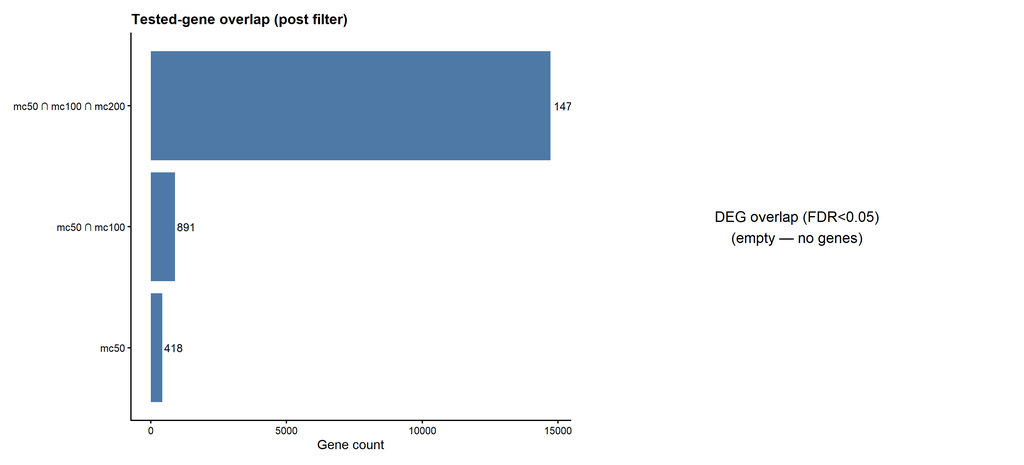

```
## Saved: sweep_overlap.(png|pdf)  [11x5 in]
```

## 2.3 Hallmark NES concordance across thresholds

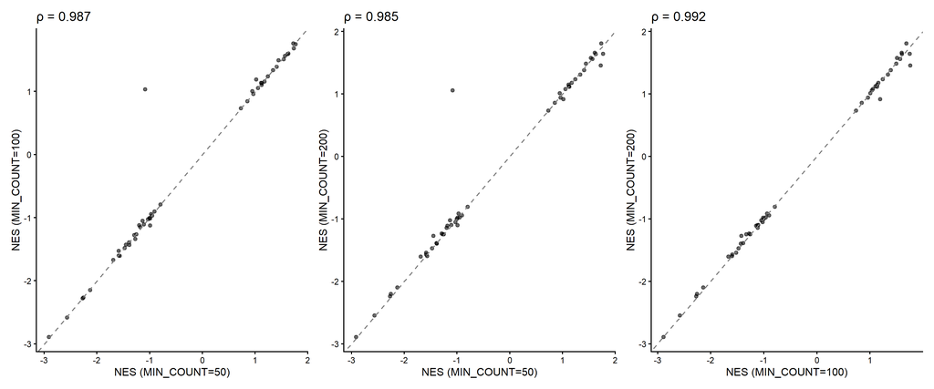

```
## Saved: sweep_hallmark_NES_concordance.(png|pdf)  [12x5 in]
```

## 2.4 Save sweep + pick working threshold

```
##
## >>> Using MIN_COUNT = 50 for §3 onward.
```

# 3. voom diagnostics + sample weights

## 3.1 Standard voom mean-variance

`voom(..., plot = TRUE)` draws its own “Mean-variance trend” title; the single-panel mean-variance figure fits comfortably at 6×5 in.

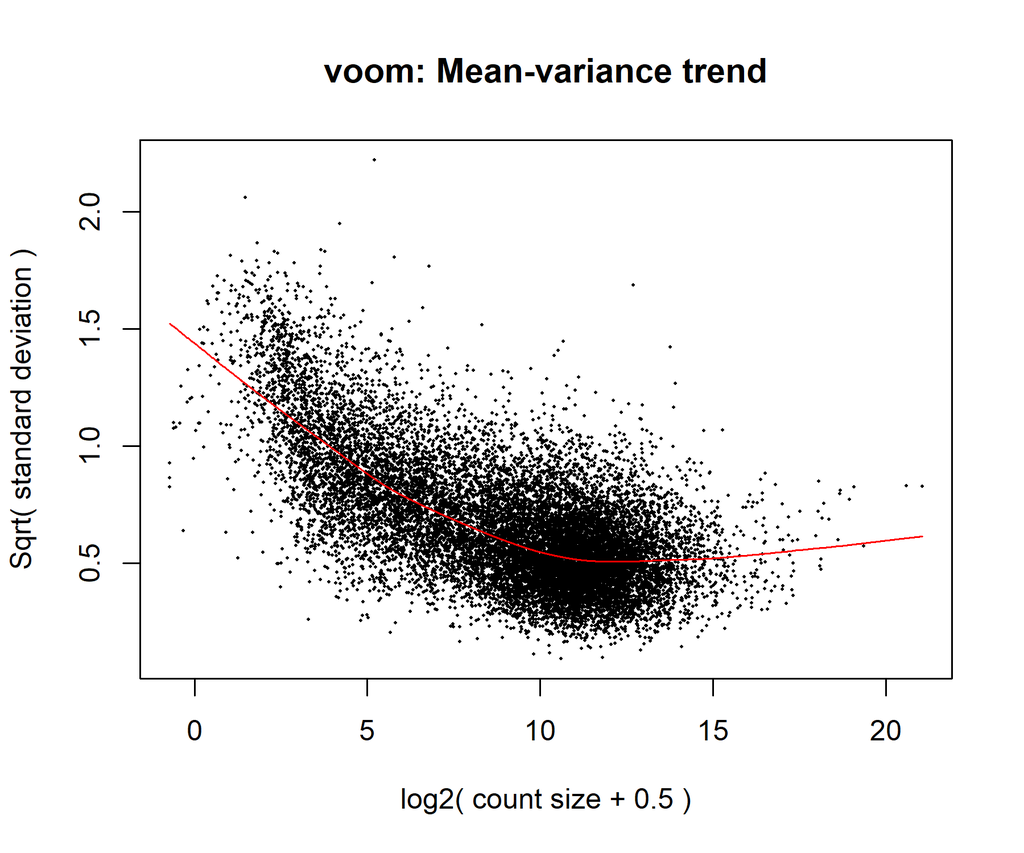

## 3.2 voomWithQualityWeights (sample weights)

`voomWithQualityWeights(..., plot = TRUE)` draws a **two-panel** layout (mean-variance on the left, per-sample weights on the right) — needs a wider canvas than the single-panel §3.1 to keep both panels readable.

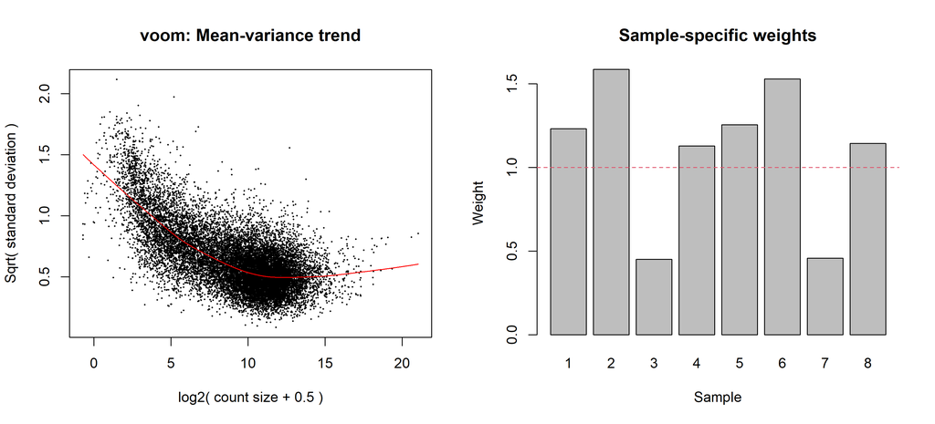

## 3.3 Per-sample weights table

Per-sample voomQW sample weights

| sample | treatment | passage | lib.size | norm.factors | sample_weight | lib.size_M |
| --- | --- | --- | --- | --- | --- | --- |
| A549-CTRL-1 | CTRL | 1 | 52258980 | 0.9360412 | 1.232 | 52.3 |
| A549-CTRL-2 | CTRL | 2 | 57719570 | 1.0083281 | 1.586 | 57.7 |
| A549-CTRL-3 | CTRL | 3 | 62025068 | 0.9967070 | 0.451 | 62.0 |
| A549-CTRL-4 | CTRL | 4 | 62104545 | 1.0380245 | 1.129 | 62.1 |
| A549-LOY-1 | LOY | 1 | 56859546 | 0.9745610 | 1.256 | 56.9 |
| A549-LOY-2 | LOY | 2 | 62235864 | 1.0607097 | 1.529 | 62.2 |
| A549-LOY-3 | LOY | 3 | 59243651 | 1.0091560 | 0.458 | 59.2 |
| A549-LOY-4 | LOY | 4 | 53446751 | 0.9816670 | 1.143 | 53.4 |

## 3.4 Weight visualization

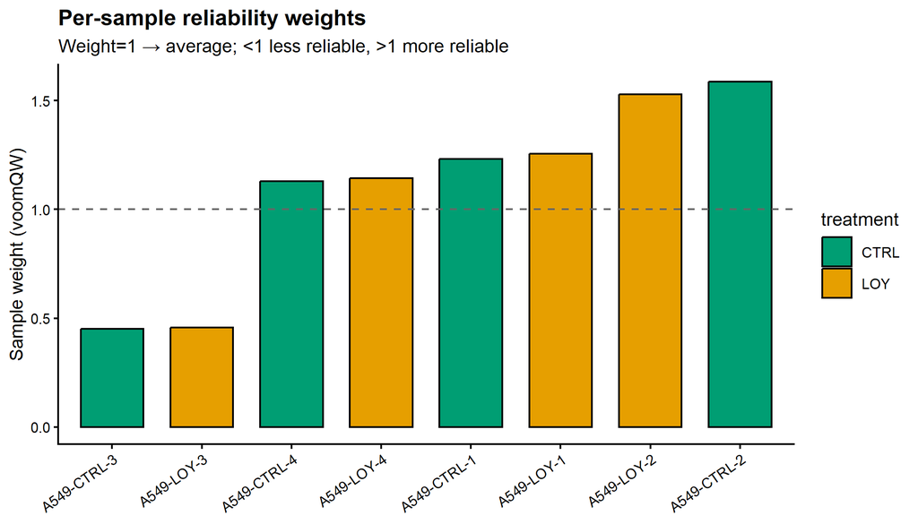

```
## Saved: voomQW_sample_weights.(png|pdf)  [7x4 in]
```

## 3.5 voom vs voomQW concordance

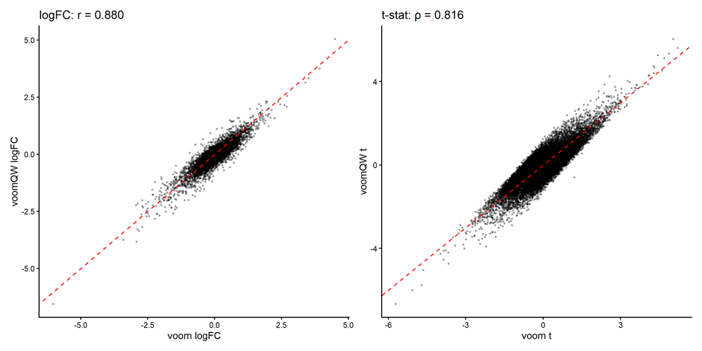

```
## Saved: voom_vs_voomQW_concordance.(png|pdf)  [10x5 in]
```

# 4. Effect-size-aware DE with `treat()`

`treat()` tests `|logFC| > LFC_THR` instead of `≠ 0`. This is what the post-hoc filter in the canonical report tried to approximate, but treat does it inside the test — giving correct p-values for the effect-size question. Run side-by-side on all three designs (paired / unpaired / pooled) so the choice of baseline is itself a robustness axis.

treat() — sig DEG counts by design (A549)

| design | n_FDR_0.05 | n_FDR_0.05_up | n_FDR_0.05_down |
| --- | --- | --- | --- |
| paired | 0 | 0 | 0 |
| unpaired | 0 | 0 | 0 |
| pooled | 0 | 0 | 0 |

## 4.0 Y-region volcano (pre-strip)

A LOY-vs-sgCTRL paired DE run on a **Y-retaining and PAR-retaining** working set (mirror of `dge0_full` above but skips the `excluded_gene_ids` strip). Every chrY (MSY-Yp / MSY-Yq) and chrX-PAR (PAR1 / PAR2) gene that passes filterByExpr appears with a real `logFC` + `FDR` value — so the volcano shows what the LOY perturbation does to the Y-linked + PAR expression landscape before §4.1+ strips those genes for downstream pathway analysis.

This view was previously impossible because the upstream STAR pipeline dropped PAR multi-mappers (all PAR genes had ~0 reads). Now that `STAR_v2_PARfix` counts are loaded (see §1.2), PAR genes have real values.

```
## Y-retaining paired DE: 16048 genes tested
```

```
##   Y-region genes: 26  [PAR1=15, PAR2=2, MSY-Yp=2, MSY-Yq=7]
```

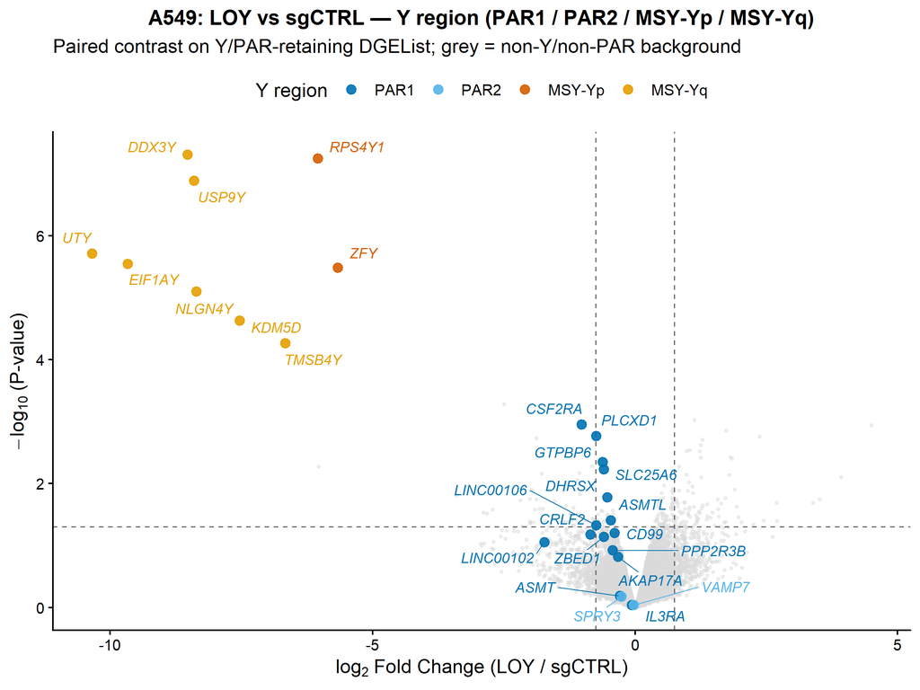

```
## Saved: volcano_LOY_v_sgCTRL_yregion.(png|pdf)  [8x6 in]
```

## 4.1 treat volcano (by design)

### Paired

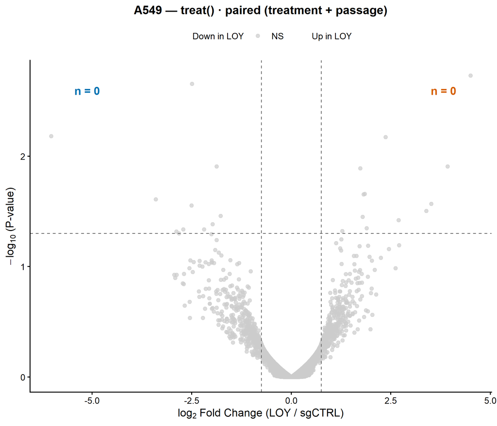

```
## Saved: volcano_treat_paired.(png|pdf)  [7x6 in]
```

### Unpaired

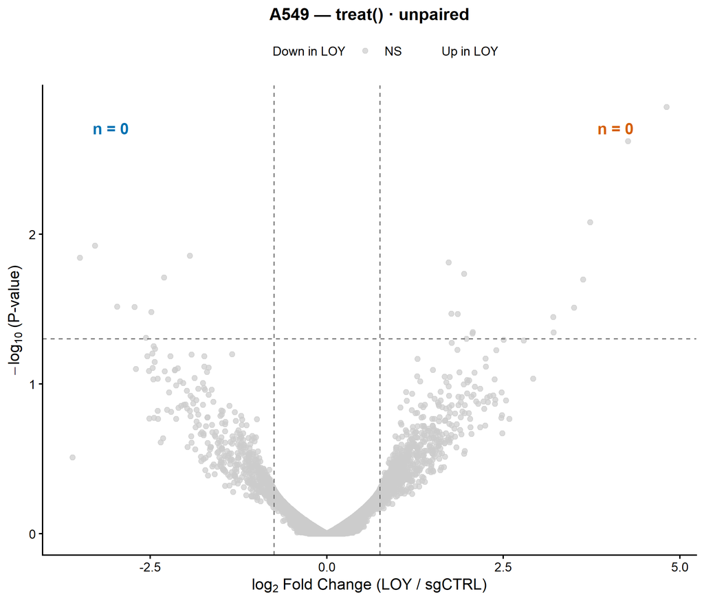

```
## Saved: volcano_treat_unpaired.(png|pdf)  [7x6 in]
```

### Pooled

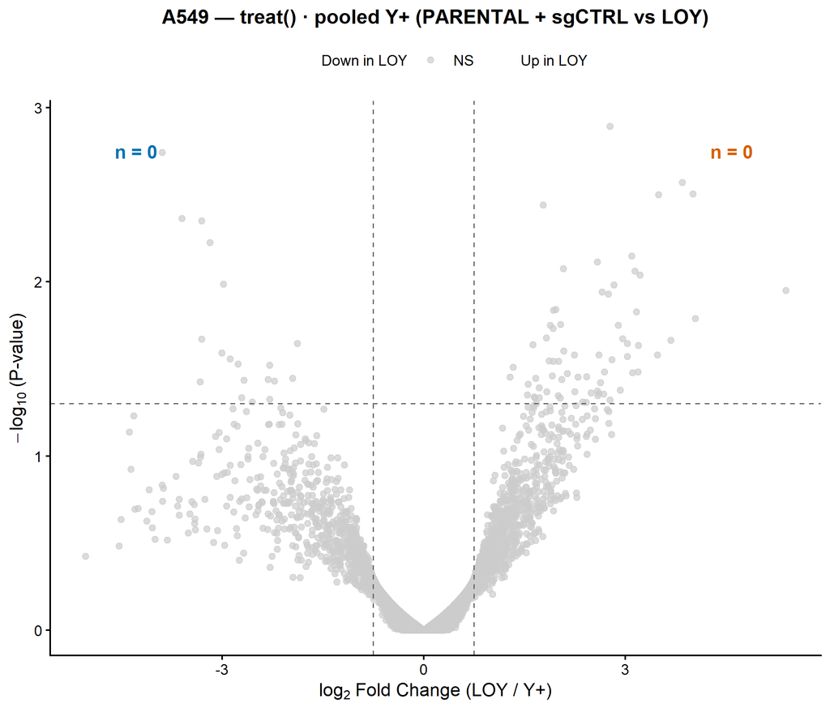

```
## Saved: volcano_treat_pooled.(png|pdf)  [7x6 in]
```

## 4.2 treat-significant vs post-hoc filtered overlap (paired)

The standard comparison: does `treat()` (effect-size-aware test) recover the same DEGs as the canonical voom + post-hoc `|lfc|>0.75` filter on the paired design? Run on paired only — the design choice is independent of the treat-vs-post-hoc comparison.

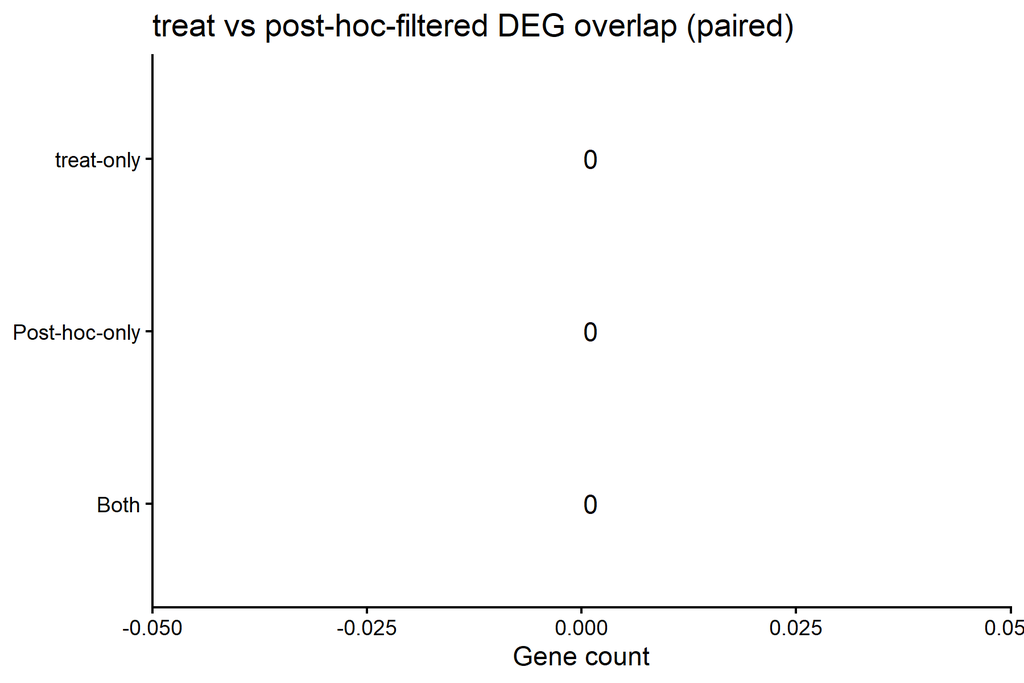

```
## Saved: treat_vs_posthoc_overlap_paired.(png|pdf)  [6x4 in]
```

## 4.3 Cross-design DEG overlap (treat)

How much of the canonical paired-treat DEG set is recovered by the unpaired and pooled designs? Strong overlap means the LOY effect is reproducible across baseline choice.

treat() DEG overlap with paired (anchor) — per design

| design | this_only | both_vs_paired | paired_only_vs_this |
| --- | --- | --- | --- |
| paired | 0 | 0 | 0 |
| unpaired | 0 | 0 | 0 |
| pooled | 0 | 0 | 0 |

# 5. edgeR quasi-likelihood cross-check

Second statistical framework on each of the three designs — voom/limma’s gaussian-on-logCPM vs edgeR’s negative-binomial-with-QL. Convergent signal across both frameworks for the same design is the strongest evidence that the LOY effect is real.

edgeR-QL sig DEG counts by design (A549)

| design | n_FDR_0.05 | n_FDR_0.05_&_lfc>thr |
| --- | --- | --- |
| paired | 0 | 0 |
| unpaired | 0 | 0 |
| pooled | 0 | 0 |

## 5.1 BCV plot (by design)

### Paired

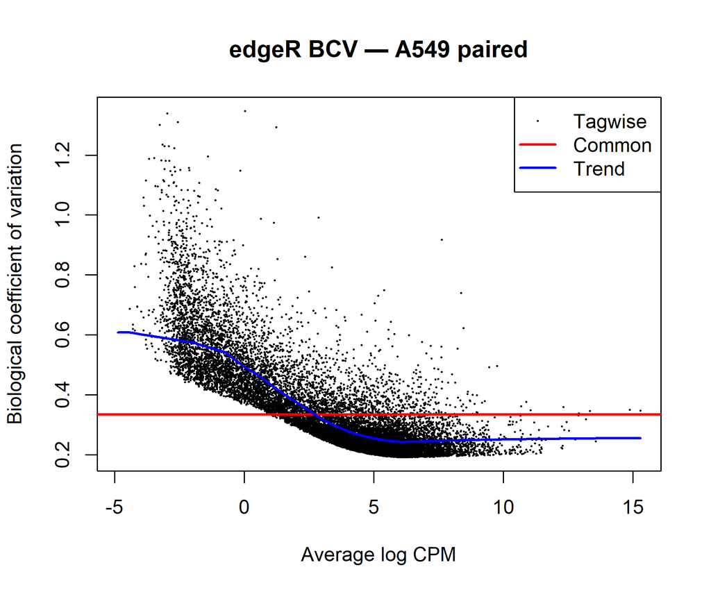

### Unpaired

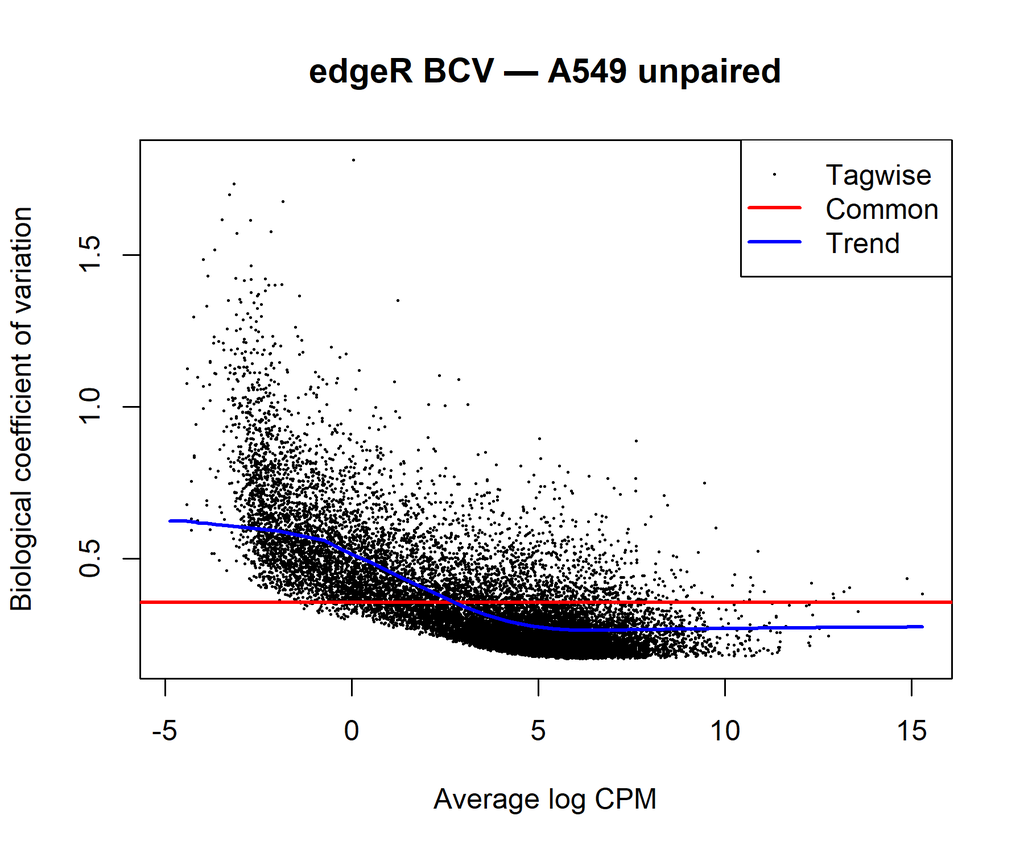

### Pooled

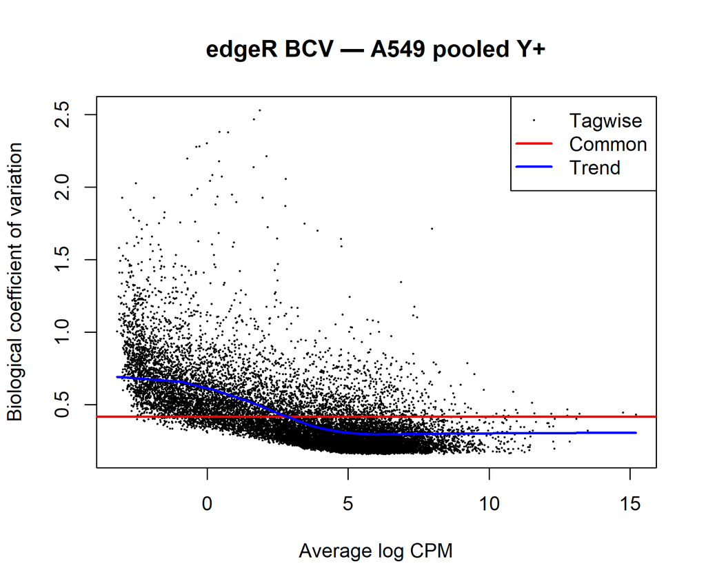

## 5.2 QL t-stat concordance with voom (by design)

### Paired

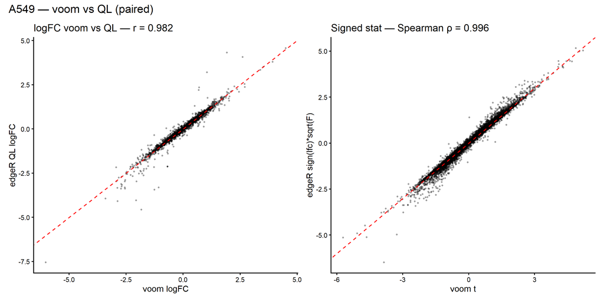

```
## Saved: voom_vs_QL_concordance_paired.(png|pdf)  [10x5 in]
```

### Unpaired

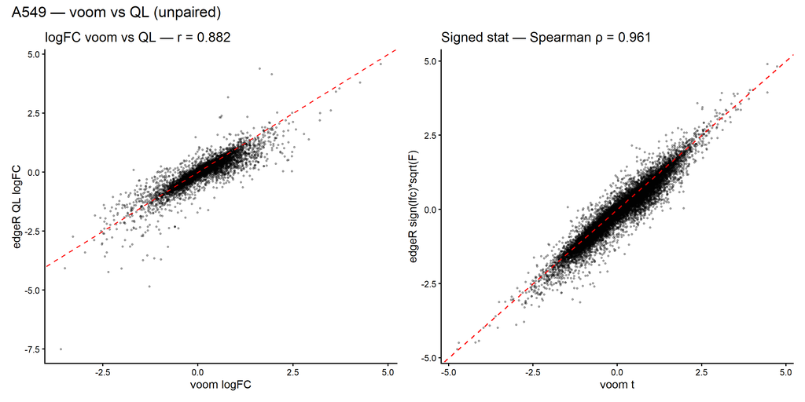

```
## Saved: voom_vs_QL_concordance_unpaired.(png|pdf)  [10x5 in]
```

### Pooled

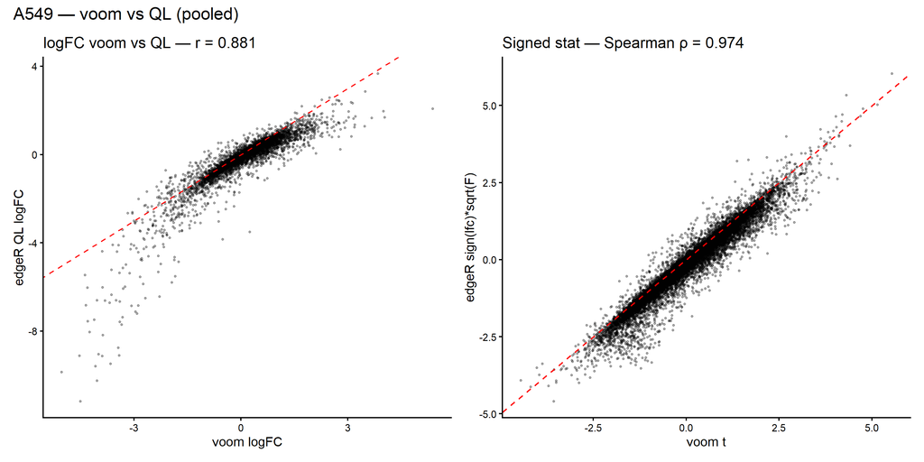

```
## Saved: voom_vs_QL_concordance_pooled.(png|pdf)  [10x5 in]
```

## 5.3 Top-200 DEG overlap (per design)

Top-200 voom ∩ top-200 QL per design (n out of 200)

| design | intersect | pct |
| --- | --- | --- |
| paired | 149 | 74.5% |
| unpaired | 147 | 73.5% |
| pooled | 99 | 49.5% |

# 6. `camera` gene-set testing

`camera` is a competitive gene-set test that accounts for inter-gene correlation — a complement to the (rank-based, correlation-naive) fgsea results in the canonical report’s §5.

```
## Loading MSigDB collections for camera...
```

camera FDR<0.05 hits by design × collection (A549)

| design | hallmark_sig | cgp_sig | reactome_sig |
| --- | --- | --- | --- |
| paired | 5 | 191 | 114 |
| unpaired | 5 | 129 | 114 |
| pooled | 12 | 313 | 0 |

## 6.1 camera vs fgsea: Hallmark side-by-side (by design)

### Paired

Top-25 Hallmark sets: camera vs fgsea (paired)

| pathway | camera_Dir | camera_FDR | camera_PValue | NES | padj_fgsea | agree |
| --- | --- | --- | --- | --- | --- | --- |
| HALLMARK_MYC_TARGETS_V2 | Down | 0.0000 | 0.0000 | -2.9143 | 0.0000 | agree Down |
| HALLMARK_MYC_TARGETS_V1 | Down | 0.0000 | 0.0000 | -2.5687 | 0.0000 | agree Down |
| HALLMARK_G2M_CHECKPOINT | Down | 0.0001 | 0.0000 | -2.2710 | 0.0000 | agree Down |
| HALLMARK_E2F_TARGETS | Down | 0.0001 | 0.0000 | -2.2561 | 0.0000 | agree Down |
| HALLMARK_MTORC1_SIGNALING | Down | 0.0004 | 0.0000 | -2.1323 | 0.0000 | agree Down |
| HALLMARK_COAGULATION | Up | 0.1011 | 0.0149 | 1.6303 | 0.0090 | agree Up |
| HALLMARK_OXIDATIVE_PHOSPHORYLATION | Down | 0.1011 | 0.0156 | -1.5896 | 0.0041 | agree Down |
| HALLMARK_PANCREAS_BETA_CELLS | Up | 0.1011 | 0.0162 | 1.7244 | 0.0351 | agree Up |
| HALLMARK_UNFOLDED_PROTEIN_RESPONSE | Down | 0.1626 | 0.0293 | -1.4761 | 0.0292 | agree Down |
| HALLMARK_WNT_BETA_CATENIN_SIGNALING | Up | 0.1654 | 0.0331 | 1.7662 | 0.0134 | agree Up |
| HALLMARK_PI3K_AKT_MTOR_SIGNALING | Down | 0.2062 | 0.0457 | -1.5893 | 0.0153 | agree Down |
| HALLMARK_MYOGENESIS | Up | 0.2062 | 0.0495 | 1.7330 | 0.0007 | agree Up |
| HALLMARK_TNFA_SIGNALING_VIA_NFKB | Down | 0.2348 | 0.0645 | -1.6930 | 0.0004 | agree Down |
| HALLMARK_P53_PATHWAY | Down | 0.2348 | 0.0657 | -1.5677 | 0.0060 | agree Down |
| HALLMARK_KRAS_SIGNALING_DN | Up | 0.2847 | 0.0854 | 1.5389 | 0.0177 | agree Up |
| HALLMARK_INTERFERON_ALPHA_RESPONSE | Down | 0.3617 | 0.1157 | -1.4501 | 0.0418 | agree Down |
| HALLMARK_DNA_REPAIR | Down | 0.4295 | 0.1460 | -1.2526 | 0.1213 | agree Down |
| HALLMARK_EPITHELIAL_MESENCHYMAL_TRANSITION | Down | 0.4610 | 0.1723 | -1.3910 | 0.0351 | agree Down |
| HALLMARK_FATTY_ACID_METABOLISM | Up | 0.4610 | 0.1752 | 1.4090 | 0.0377 | agree Up |
| HALLMARK_BILE_ACID_METABOLISM | Up | 0.4664 | 0.1866 | 1.6127 | 0.0177 | agree Up |
| HALLMARK_MITOTIC_SPINDLE | Down | 0.4775 | 0.2006 | -1.1094 | 0.3125 | agree Down |
| HALLMARK_INTERFERON_GAMMA_RESPONSE | Down | 0.5753 | 0.2531 | -1.3877 | 0.0496 | agree Down |
| HALLMARK_NOTCH_SIGNALING | Up | 0.5814 | 0.2675 | 1.5649 | 0.0739 | agree Up |
| HALLMARK_APOPTOSIS | Down | 0.6374 | 0.3062 | -1.1820 | 0.2102 | agree Down |
| HALLMARK_HYPOXIA | Up | 0.6374 | 0.3187 | 1.3372 | 0.0753 | agree Up |

```
## Direction agreement: 47 / 50
```

### Unpaired

Top-25 Hallmark sets: camera vs fgsea (unpaired)

| pathway | camera_Dir | camera_FDR | camera_PValue | NES | padj_fgsea | agree |
| --- | --- | --- | --- | --- | --- | --- |
| HALLMARK_MYC_TARGETS_V2 | Down | 0.0000 | 0.0000 | -2.7540 | 0.0000 | agree Down |
| HALLMARK_MYC_TARGETS_V1 | Down | 0.0003 | 0.0000 | -2.5336 | 0.0000 | agree Down |
| HALLMARK_G2M_CHECKPOINT | Down | 0.0005 | 0.0000 | -2.3205 | 0.0000 | agree Down |
| HALLMARK_E2F_TARGETS | Down | 0.0007 | 0.0001 | -2.3116 | 0.0000 | agree Down |
| HALLMARK_MTORC1_SIGNALING | Down | 0.0007 | 0.0001 | -2.1558 | 0.0000 | agree Down |
| HALLMARK_COAGULATION | Up | 0.0734 | 0.0088 | 1.7026 | 0.0051 | agree Up |
| HALLMARK_OXIDATIVE_PHOSPHORYLATION | Down | 0.0734 | 0.0103 | -1.5738 | 0.0026 | agree Down |
| HALLMARK_UNFOLDED_PROTEIN_RESPONSE | Down | 0.1289 | 0.0206 | -1.4802 | 0.0263 | agree Down |
| HALLMARK_PI3K_AKT_MTOR_SIGNALING | Down | 0.1851 | 0.0350 | -1.5945 | 0.0117 | agree Down |
| HALLMARK_P53_PATHWAY | Down | 0.1851 | 0.0394 | -1.6662 | 0.0008 | agree Down |
| HALLMARK_WNT_BETA_CATENIN_SIGNALING | Up | 0.1851 | 0.0434 | 1.7338 | 0.0117 | agree Up |
| HALLMARK_TNFA_SIGNALING_VIA_NFKB | Down | 0.1851 | 0.0444 | -1.6403 | 0.0009 | agree Down |
| HALLMARK_PANCREAS_BETA_CELLS | Up | 0.1863 | 0.0484 | 1.5044 | 0.1022 | agree Up |
| HALLMARK_EPITHELIAL_MESENCHYMAL_TRANSITION | Down | 0.2555 | 0.0715 | -1.5662 | 0.0053 | agree Down |
| HALLMARK_KRAS_SIGNALING_DN | Up | 0.3206 | 0.0962 | 1.3645 | 0.0815 | agree Up |
| HALLMARK_MYOGENESIS | Up | 0.4000 | 0.1280 | 1.5157 | 0.0167 | agree Up |
| HALLMARK_DNA_REPAIR | Down | 0.4418 | 0.1517 | -1.0502 | 0.5517 | agree Down |
| HALLMARK_INTERFERON_ALPHA_RESPONSE | Down | 0.4418 | 0.1662 | -1.3899 | 0.0798 | agree Down |
| HALLMARK_MITOTIC_SPINDLE | Down | 0.4418 | 0.1732 | -1.0065 | 0.6454 | agree Down |
| HALLMARK_APOPTOSIS | Down | 0.4418 | 0.1767 | -1.2494 | 0.1022 | agree Down |
| HALLMARK_BILE_ACID_METABOLISM | Up | 0.5294 | 0.2291 | 1.5247 | 0.0263 | agree Up |
| HALLMARK_PROTEIN_SECRETION | Down | 0.5294 | 0.2394 | -0.8993 | 0.7831 | agree Down |
| HALLMARK_ADIPOGENESIS | Down | 0.5294 | 0.2435 | -0.9901 | 0.6454 | agree Down |
| HALLMARK_FATTY_ACID_METABOLISM | Up | 0.5989 | 0.2875 | 1.3372 | 0.0938 | agree Up |
| HALLMARK_REACTIVE_OXYGEN_SPECIES_PATHWAY | Down | 0.6220 | 0.3230 | -0.8645 | 0.7831 | agree Down |

```
## Direction agreement: 44 / 50
```

### Pooled

Top-25 Hallmark sets: camera vs fgsea (pooled)

| pathway | camera_Dir | camera_FDR | camera_PValue | NES | padj_fgsea | agree |
| --- | --- | --- | --- | --- | --- | --- |
| HALLMARK_TNFA_SIGNALING_VIA_NFKB | Down | 0.0000 | 0.0000 | -2.7049 | 0.0000 | agree Down |
| HALLMARK_INTERFERON_ALPHA_RESPONSE | Down | 0.0000 | 0.0000 | -2.6520 | 0.0000 | agree Down |
| HALLMARK_INTERFERON_GAMMA_RESPONSE | Down | 0.0000 | 0.0000 | -2.4595 | 0.0000 | agree Down |
| HALLMARK_INFLAMMATORY_RESPONSE | Down | 0.0000 | 0.0000 | -2.3996 | 0.0000 | agree Down |
| HALLMARK_MTORC1_SIGNALING | Down | 0.0006 | 0.0001 | -2.1083 | 0.0000 | agree Down |
| HALLMARK_EPITHELIAL_MESENCHYMAL_TRANSITION | Down | 0.0011 | 0.0001 | -2.2184 | 0.0000 | agree Down |
| HALLMARK_MYC_TARGETS_V2 | Down | 0.0012 | 0.0002 | -2.1499 | 0.0001 | agree Down |
| HALLMARK_IL6_JAK_STAT3_SIGNALING | Down | 0.0035 | 0.0006 | -2.0914 | 0.0001 | agree Down |
| HALLMARK_UNFOLDED_PROTEIN_RESPONSE | Down | 0.0092 | 0.0017 | -1.9255 | 0.0001 | agree Down |
| HALLMARK_MYC_TARGETS_V1 | Down | 0.0106 | 0.0021 | -2.0451 | 0.0000 | agree Down |
| HALLMARK_G2M_CHECKPOINT | Down | 0.0133 | 0.0029 | -1.8150 | 0.0000 | agree Down |
| HALLMARK_COMPLEMENT | Down | 0.0140 | 0.0034 | -1.8320 | 0.0000 | agree Down |
| HALLMARK_PI3K_AKT_MTOR_SIGNALING | Down | 0.0576 | 0.0156 | -1.7108 | 0.0026 | agree Down |
| HALLMARK_PROTEIN_SECRETION | Down | 0.0576 | 0.0176 | -1.6300 | 0.0107 | agree Down |
| HALLMARK_E2F_TARGETS | Down | 0.0576 | 0.0188 | -1.6135 | 0.0006 | agree Down |
| HALLMARK_ALLOGRAFT_REJECTION | Down | 0.0576 | 0.0195 | -1.6929 | 0.0010 | agree Down |
| HALLMARK_KRAS_SIGNALING_DN | Up | 0.0576 | 0.0196 | 1.5465 | 0.0107 | agree Up |
| HALLMARK_APOPTOSIS | Down | 0.0624 | 0.0225 | -1.5703 | 0.0029 | agree Down |
| HALLMARK_IL2_STAT5_SIGNALING | Down | 0.0936 | 0.0356 | -1.4094 | 0.0281 | agree Down |
| HALLMARK_UV_RESPONSE_UP | Down | 0.1457 | 0.0583 | -1.5397 | 0.0049 | agree Down |
| HALLMARK_HEME_METABOLISM | Down | 0.1534 | 0.0644 | -1.4852 | 0.0075 | agree Down |
| HALLMARK_KRAS_SIGNALING_UP | Down | 0.1578 | 0.0698 | -1.6806 | 0.0009 | agree Down |
| HALLMARK_OXIDATIVE_PHOSPHORYLATION | Down | 0.1578 | 0.0726 | -1.2765 | 0.0643 | agree Down |
| HALLMARK_HYPOXIA | Down | 0.1895 | 0.0913 | -1.3582 | 0.0335 | agree Down |
| HALLMARK_TGF_BETA_SIGNALING | Down | 0.1895 | 0.0947 | -1.2479 | 0.1440 | agree Down |

```
## Direction agreement: 44 / 50
```

## 6.2 camera Hallmark dotplot (by design)

### Paired

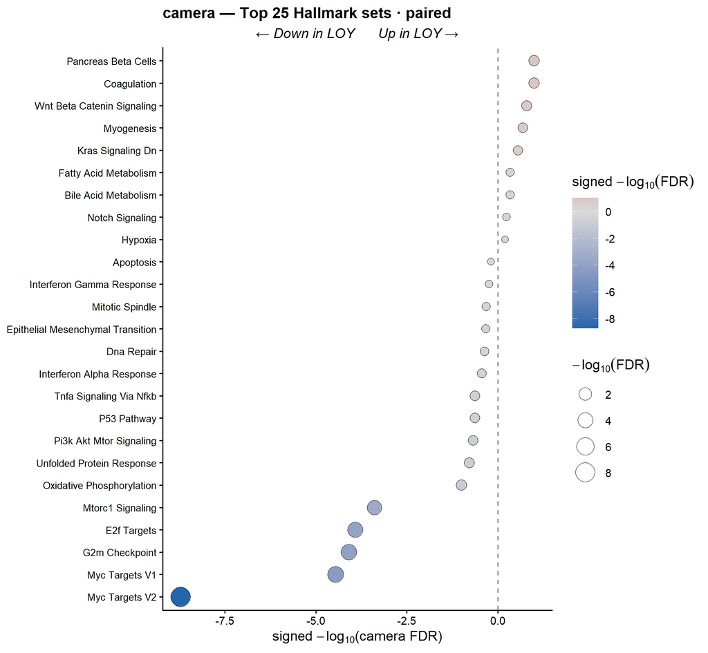

```
## Saved: camera_hallmark_dotplot_paired.(png|pdf)  [6.5x6 in]
```

### Unpaired

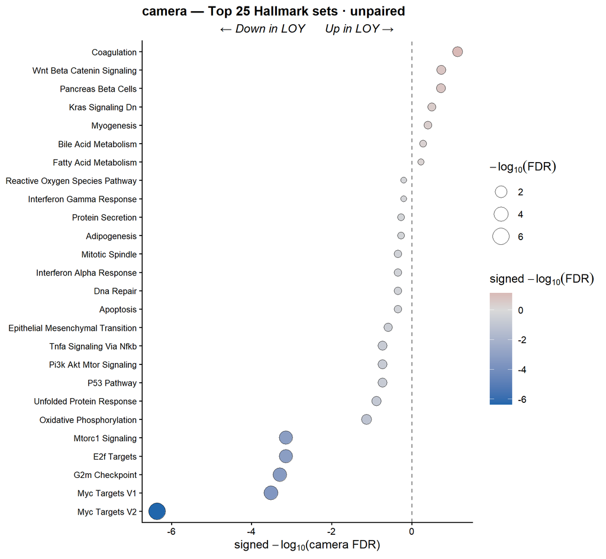

```
## Saved: camera_hallmark_dotplot_unpaired.(png|pdf)  [6.5x6 in]
```

### Pooled

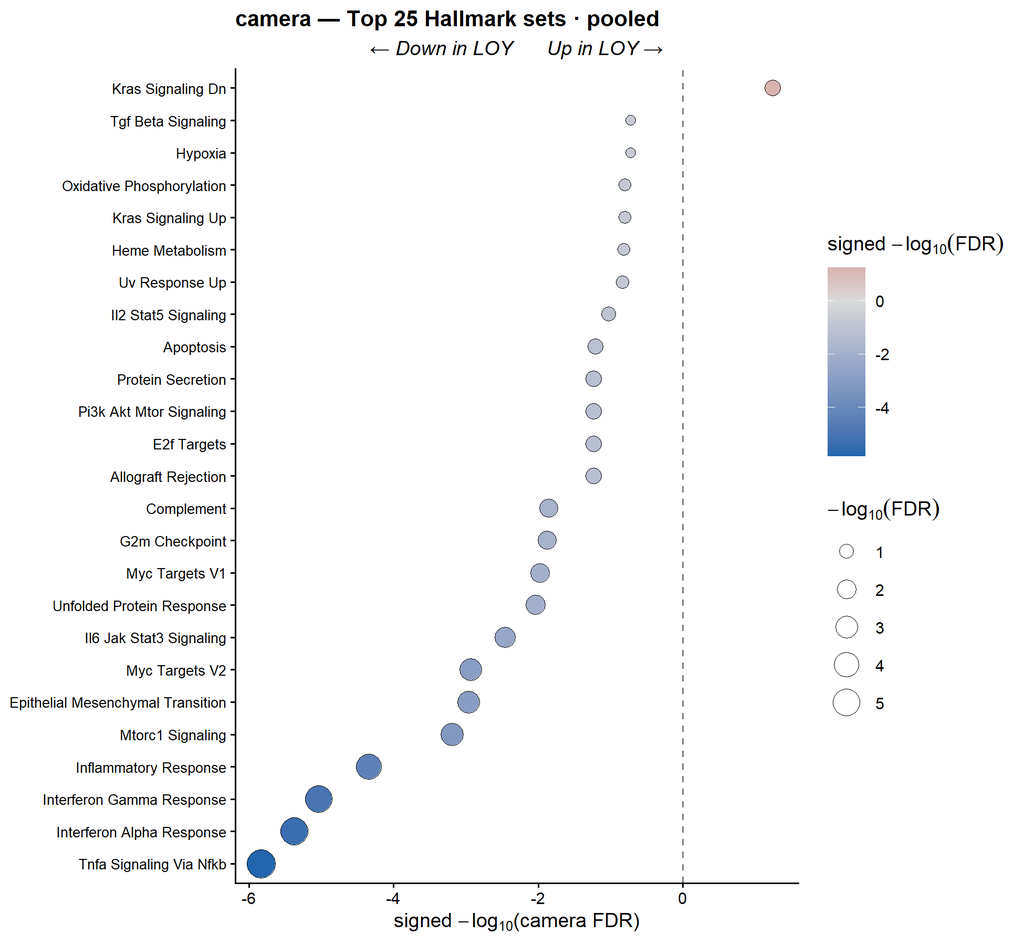

```
## Saved: camera_hallmark_dotplot_pooled.(png|pdf)  [6.5x6 in]
```

# 7. Sex-chromosome homologs / Y-linked paralog deep-dive

```
## Paralog genes detected: 18 / 20
```

```
## Missing (filtered out or unannotated):  PRKY, NLGN4X
```

## 7.1 Per-pair boxplots

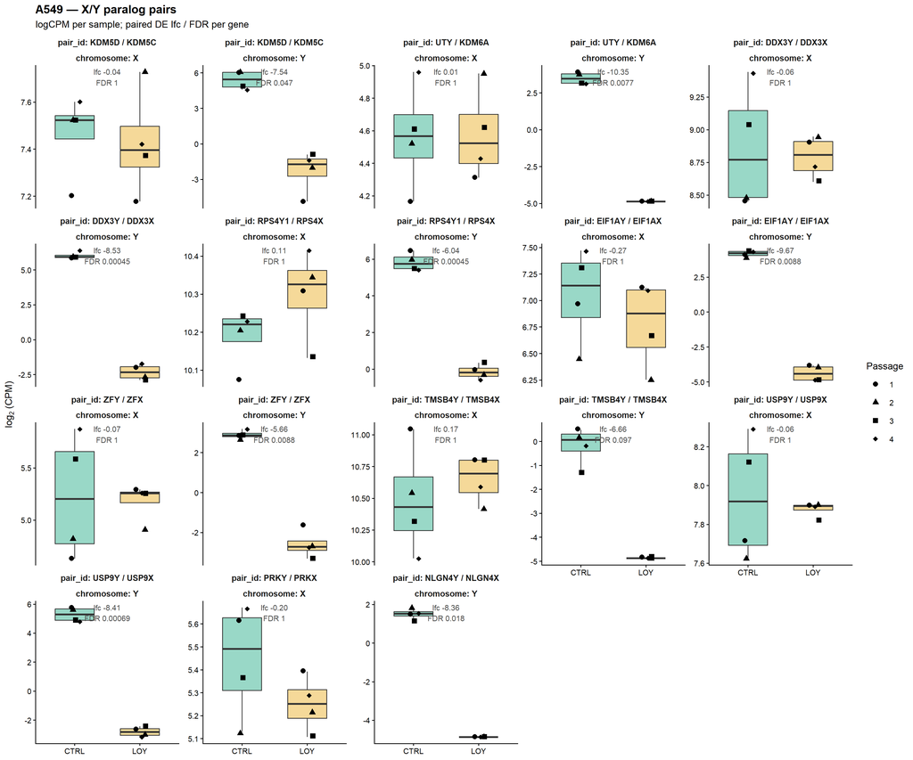

```
## Saved: paralog_boxplots.(png|pdf)  [12x10 in]
```

## 7.2 Y-gene logFC vs paralogous X-gene logFC

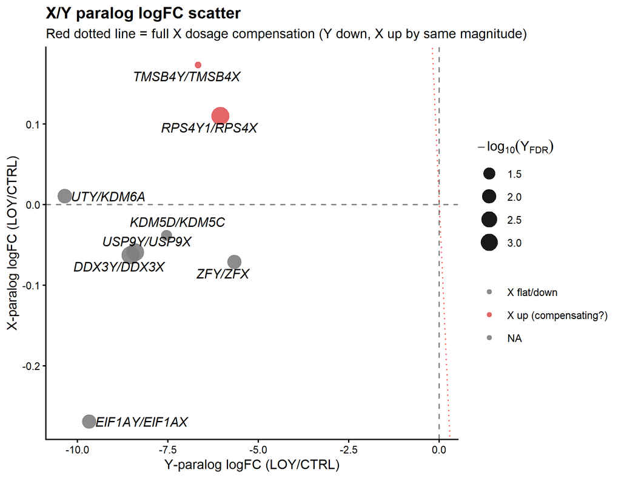

```
## Saved: paralog_logFC_scatter.(png|pdf)  [6.5x5 in]
```

## 7.3 Dosage-compensation index

X/Y paralog dosage-compensation summary

| pair | Y | Y_logFC | Y_FDR | X | X_logFC | X_FDR | compensation_index | interpretation |
| --- | --- | --- | --- | --- | --- | --- | --- | --- |
| UTY/KDM6A | UTY | -10.347 | 0.008 | KDM6A | 0.011 | 1 | -10.337 | X flat (no compensation) |
| EIF1AY/EIF1AX | EIF1AY | -9.668 | 0.009 | EIF1AX | -0.269 | 1 | -9.937 | X also down (co-regulated?) |
| DDX3Y/DDX3X | DDX3Y | -8.531 | 0.000 | DDX3X | -0.063 | 1 | -8.594 | X flat (no compensation) |
| USP9Y/USP9X | USP9Y | -8.406 | 0.001 | USP9X | -0.059 | 1 | -8.465 | X flat (no compensation) |
| NLGN4Y/NLGN4X | NLGN4Y | -8.363 | 0.018 | NLGN4X | NA | NA | NA | Y changed (other dir) |
| KDM5D/KDM5C | KDM5D | -7.537 | 0.047 | KDM5C | -0.039 | 1 | -7.576 | X flat (no compensation) |
| TMSB4Y/TMSB4X | TMSB4Y | -6.664 | 0.097 | TMSB4X | 0.173 | 1 | -6.491 | X flat (no compensation) |
| RPS4Y1/RPS4X | RPS4Y1 | -6.043 | 0.000 | RPS4X | 0.110 | 1 | -5.933 | X flat (no compensation) |
| ZFY/ZFX | ZFY | -5.662 | 0.009 | ZFX | -0.071 | 1 | -5.734 | X flat (no compensation) |
| PRKY/PRKX | PRKY | NA | NA | PRKX | -0.197 | 1 | NA | Y changed (other dir) |

## 7.4 Paralog heatmap

Side-by-side z-scaled logCPM heatmap of the X/Y paralog pairs. The default LOY-vs-sgCTRL tab matches the rest of §7 (paired contrast working set). The “with PARENTAL” tab adds the 3 PARENTAL samples as an untreated baseline — useful for spotting whether any X/Y paralog drift in LOY also appears between PARENTAL and sgCTRL (a sgRNA artifact rather than LOY biology).

### LOY vs sgCTRL only

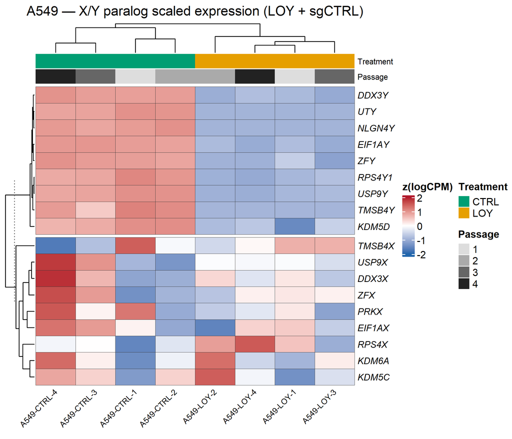

```
## Saved: paralog_heatmap.(png|pdf)
```

### With PARENTAL

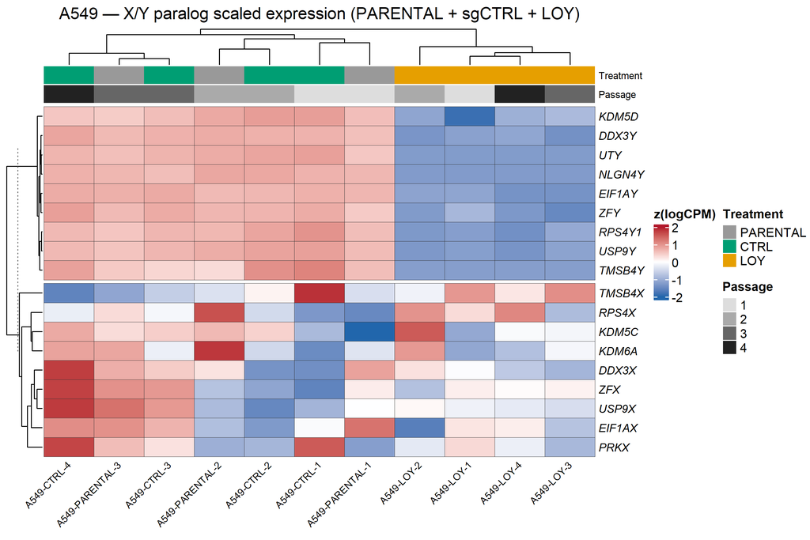

```
## Saved: paralog_heatmap_with_parental.(png|pdf)
```

# 8. Sample-level pathway scoring

Goal: instead of contrast-level enrichment, score each Hallmark / PROGENy / custom signature per sample, then test the score with the paired model.

## 8.1 GSVA / ssGSEA on Hallmark

```
## ssGSEA: 50 Hallmark sets x 8 samples
```

## 8.2 PROGENy pathway activity

```
## PROGENy: 14 pathways x 8 samples
```

## 8.3 decoupleR-PROGENy (cross-method check)

```
## decoupleR-PROGENy: 14 pathways x 8 samples
```

## 8.4 PROGENy vs decoupleR-PROGENy concordance

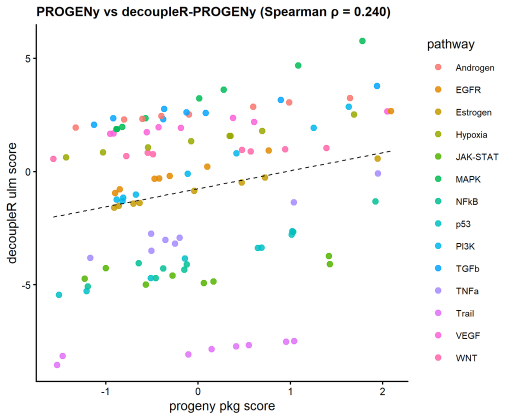

```
## Saved: progeny_vs_decoupleR_concord.(png|pdf)  [5.5x4.5 in]
```

```
## Custom signature sizes (after gene-matrix filter):
```

```
## PRC2_bivalent   chrY_coding
##          1347             9
```

## 8.6 LM test on each score (paired vs unpaired)

Per-pathway score shift tested against treatment. Paired (`~ treatment + passage`) is the canonical analysis; unpaired (`~ treatment`) is the robustness comparison — agreement between the two means the passage block isn’t carrying the signal.

### Paired

```
## Top 15 sample-level pathway score shifts (paired):
```

| pathway | method | beta_LOY | SE | p_value | FDR |
| --- | --- | --- | --- | --- | --- |
| chrY_coding | ssGSEA_custom | -0.899 | 0.041 | 0.0002 | 0.0004 |
| JAK-STAT | decoupleR_PROGENy | -0.573 | 0.181 | 0.0507 | 0.7097 |
| HALLMARK_PANCREAS_BETA_CELLS | ssGSEA_hallmark | 0.015 | 0.007 | 0.1143 | 0.9776 |
| HALLMARK_MYOGENESIS | ssGSEA_hallmark | 0.014 | 0.007 | 0.1355 | 0.9776 |
| HALLMARK_ANGIOGENESIS | ssGSEA_hallmark | 0.016 | 0.009 | 0.1830 | 0.9776 |
| Trail | PROGENy | 0.816 | 0.542 | 0.2293 | 0.8518 |
| HALLMARK_FATTY_ACID_METABOLISM | ssGSEA_hallmark | 0.013 | 0.009 | 0.2401 | 0.9776 |
| HALLMARK_KRAS_SIGNALING_DN | ssGSEA_hallmark | 0.019 | 0.013 | 0.2518 | 0.9776 |
| Trail | decoupleR_PROGENy | 0.210 | 0.155 | 0.2676 | 0.8089 |
| HALLMARK_BILE_ACID_METABOLISM | ssGSEA_hallmark | 0.010 | 0.008 | 0.2919 | 0.9776 |
| JAK-STAT | PROGENy | -1.007 | 0.793 | 0.2937 | 0.8518 |
| WNT | decoupleR_PROGENy | 0.092 | 0.074 | 0.3018 | 0.8089 |
| EGFR | PROGENy | -0.741 | 0.621 | 0.3190 | 0.8518 |
| PI3K | decoupleR_PROGENy | -1.076 | 0.913 | 0.3237 | 0.8089 |
| EGFR | decoupleR_PROGENy | -0.847 | 0.737 | 0.3335 | 0.8089 |

### Unpaired

```
## Top 15 sample-level pathway score shifts (unpaired):
```

| pathway | method | beta_LOY | SE | p_value | FDR |
| --- | --- | --- | --- | --- | --- |
| chrY_coding | ssGSEA_custom | -0.899 | 0.036 | 0.0000 | 0.0000 |
| JAK-STAT | decoupleR_PROGENy | -0.573 | 0.252 | 0.0630 | 0.7434 |
| HALLMARK_ANGIOGENESIS | ssGSEA_hallmark | 0.016 | 0.009 | 0.1500 | 0.9755 |
| HALLMARK_PANCREAS_BETA_CELLS | ssGSEA_hallmark | 0.015 | 0.009 | 0.1511 | 0.9755 |
| JAK-STAT | PROGENy | -1.007 | 0.644 | 0.1688 | 0.8387 |
| HALLMARK_FATTY_ACID_METABOLISM | ssGSEA_hallmark | 0.013 | 0.008 | 0.1808 | 0.9755 |
| HALLMARK_KRAS_SIGNALING_DN | ssGSEA_hallmark | 0.019 | 0.013 | 0.1963 | 0.9755 |
| HALLMARK_NOTCH_SIGNALING | ssGSEA_hallmark | 0.013 | 0.009 | 0.2137 | 0.9755 |
| Trail | PROGENy | 0.816 | 0.687 | 0.2800 | 0.8387 |
| HALLMARK_WNT_BETA_CATENIN_SIGNALING | ssGSEA_hallmark | 0.012 | 0.010 | 0.2883 | 0.9755 |
| HALLMARK_MYOGENESIS | ssGSEA_hallmark | 0.014 | 0.012 | 0.3014 | 0.9755 |
| EGFR | PROGENy | -0.741 | 0.701 | 0.3316 | 0.8387 |
| EGFR | decoupleR_PROGENy | -0.847 | 0.823 | 0.3427 | 0.7434 |
| Hypoxia | decoupleR_PROGENy | 0.417 | 0.424 | 0.3636 | 0.7434 |
| PI3K | decoupleR_PROGENy | -1.076 | 1.147 | 0.3846 | 0.7434 |

## 8.7 Heatmap of Hallmark scores

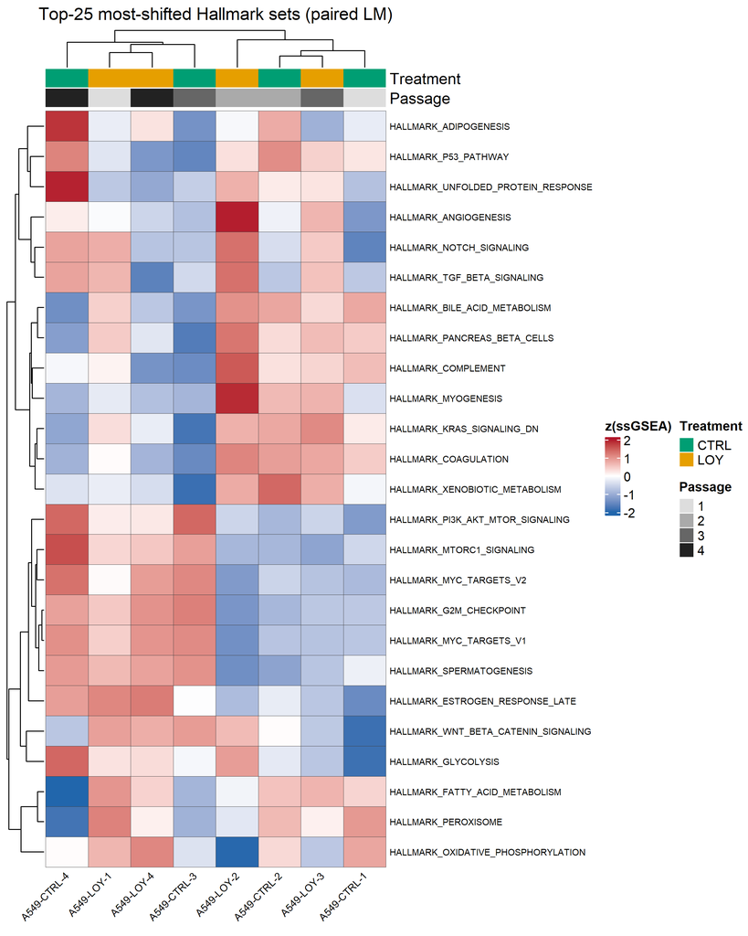

## 8.8 Top-6 score boxplots

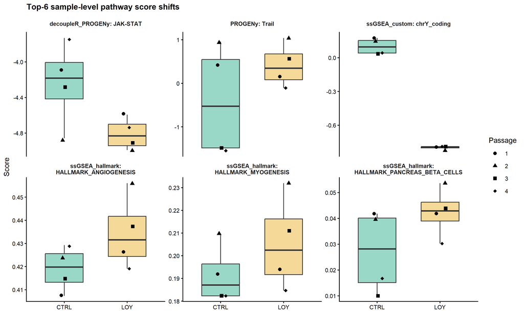

```
## Saved: top6_pathway_score_boxplots.(png|pdf)  [10x6 in]
```

# 9. lpWGS copy-number integration

**Data**: A549 lpWGS (`A549-sgCTRL-D0`, `A549-LOY-D0` — limited replicates, single timepoint, T2T-CHM13v2.0). Pre-segmented by QDNAseq in `projects/WGS/code/coverage_report_A549_QDNAseq.Rmd`, exported as `A549_QDNAseq_cn.rds` + `A549_QDNAseq_cn_df.rds`. With only one or two samples per arm, CN is treated as a **population backdrop** for the RNAseq contrast — not per-replicate matched.

## 9.1 Load CN object

```
## Loaded CN: 31185 bins x 2 samples (T2T-CHM13)
```

```
## [1] sgCTRL LOY
## Levels: sgCTRL LOY
```

## 9.2 Build T2T-CHM13 gene coordinate index

```
## Loading T2T-CHM13v2.0 GTF (may take ~30s)...
```

```
## T2T gene index: 57711 genes across chroms chr1,chr2,chr3,chr4,chr5,chr6,chr7,chr8,chr9,chr10,chr11,chr12,chr13,chr14,chr15,chr16,chr17,chr18,chr19,chr20,chr21,chr22,chrX,chrY
```

## 9.3 Overlap RNA genes onto QDNAseq bins

```
## Genes with CN mapping: 14874 / 16036 in DE
```

## 9.4 Annotate DE table with CN

```
## DEGs (FDR<0.05) flagged as CN-driven:  0  /  0
```

## 9.5 DEG volcano colored by CN state — cutoff sweep

The classifier compares each gene’s lpWGS `cn_delta = log2(LOY/sgCTRL)` at its bin to a Gain/Loss cutoff. The sensible range is 0.3–0.5 (0.3 ≈ 1.23× signal shift, 0.5 ≈ 1.41× shift). Three tabs at 0.3 / 0.4 / 0.5; tighter cutoffs keep only the most confident CN shifts. The 3-across composite is also saved to disk as `volcano_LOY_v_sgCTRL_cn_cutoff_sweep.(png|pdf)`.

```
## Saved: volcano_LOY_v_sgCTRL_cn_cutoff_sweep.(png|pdf)  [18x6 in]
```

### |cn_delta| > 0.3

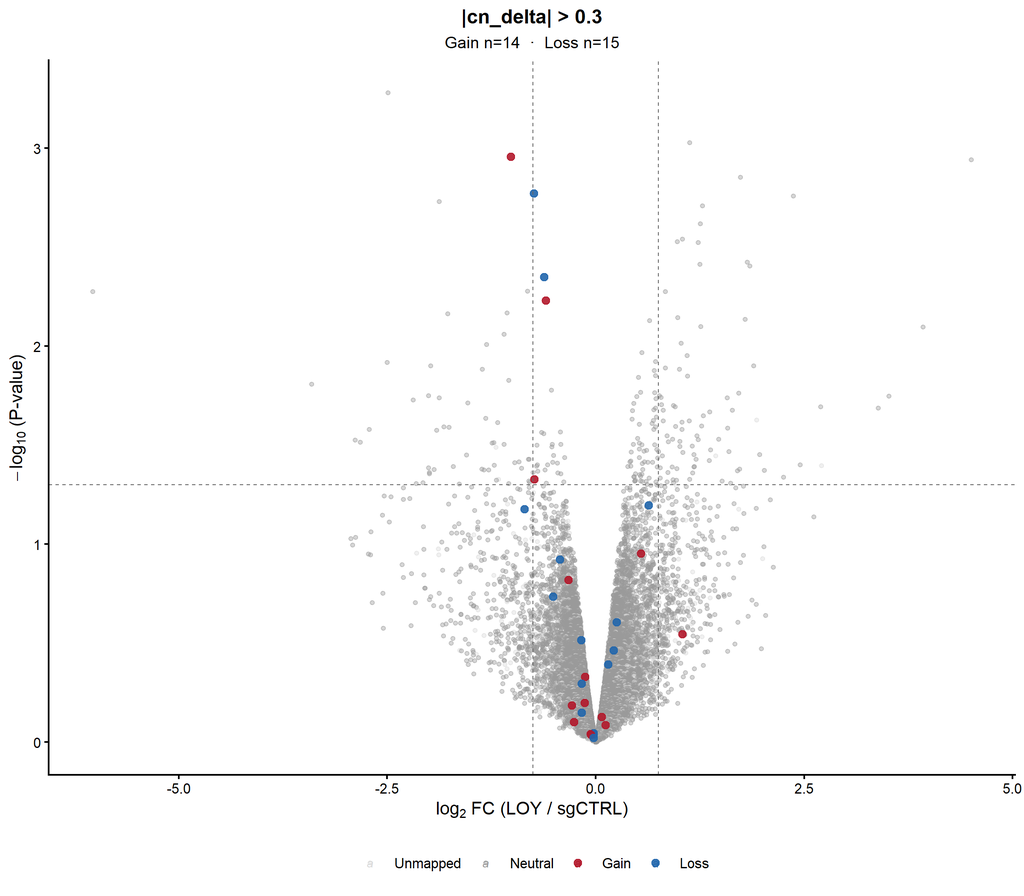

### |cn_delta| > 0.4

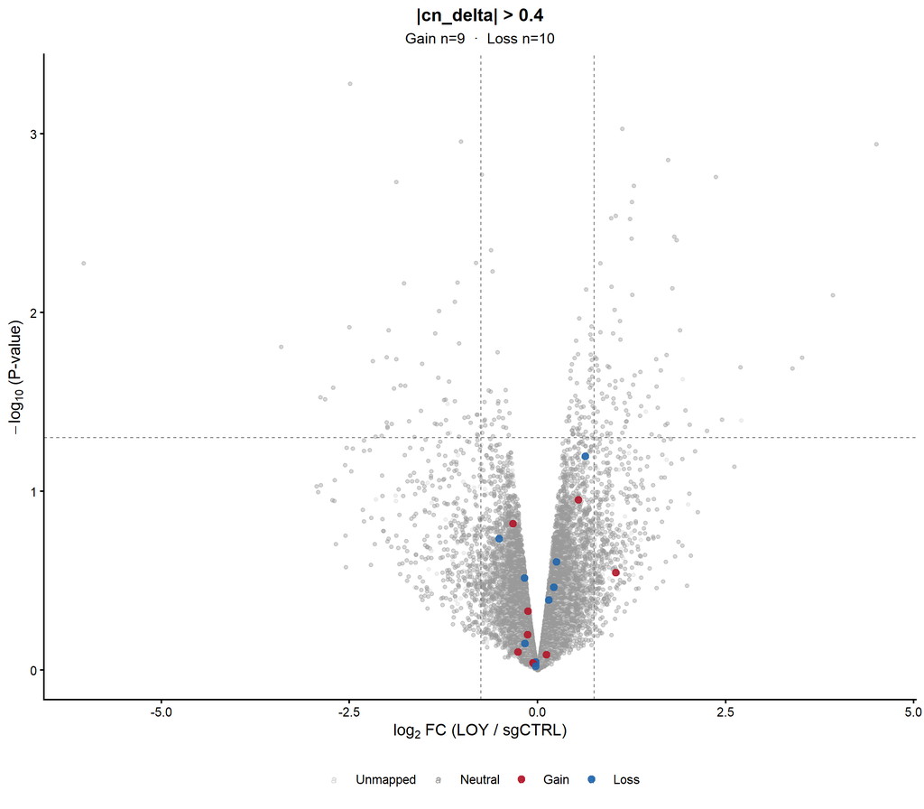

### |cn_delta| > 0.5

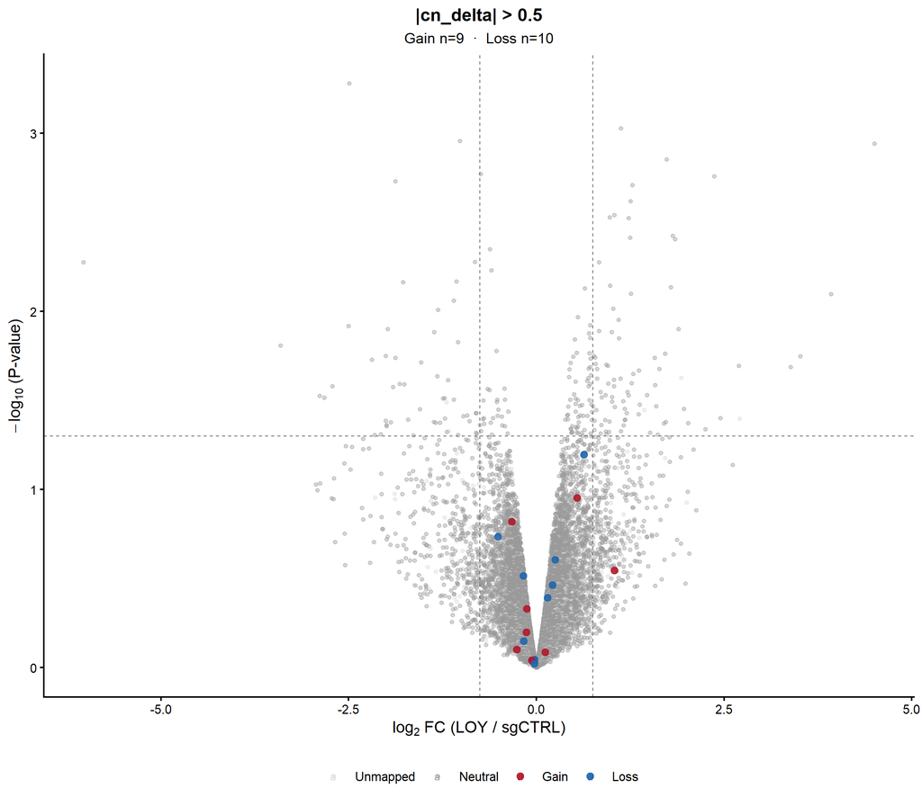

### Gene counts by cutoff

Gene counts by cn_delta cutoff (Gain_among_sig / Loss_among_sig restricted to FDR<0.05 & |logFC|>0.75)

| cutoff | Gain | Loss | Neutral | Unmapped | Gain_among_sig | Loss_among_sig |
| --- | --- | --- | --- | --- | --- | --- |
| 0.3 | 14 | 15 | 14848 | 1162 | 0 | 0 |
| 0.4 | 9 | 10 | 14858 | 1162 | 0 | 0 |
| 0.5 | 9 | 10 | 14858 | 1162 | 0 | 0 |

## 9.6 Chromosome-arm mean shifts

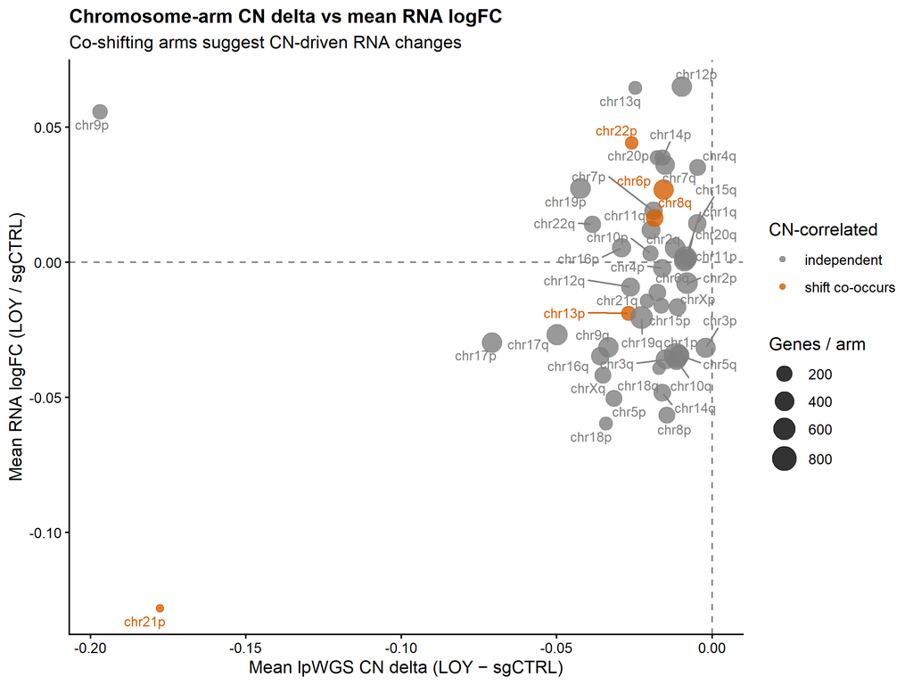

```
## Saved: chromosome_arm_CN_vs_RNA.(png|pdf)  [8x6 in]
```

## 9.7 Per-gene CN delta vs logFC scatter

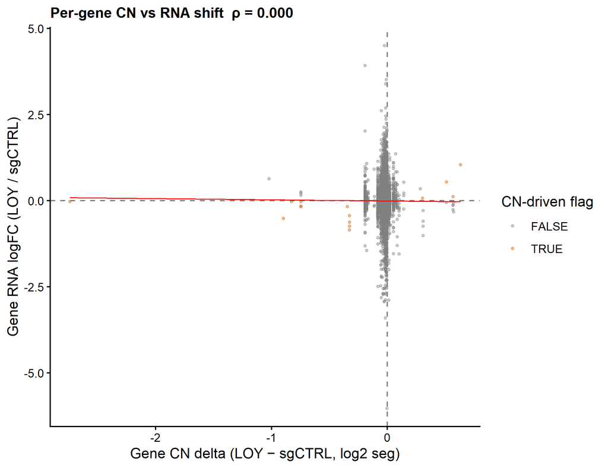

```
## Saved: per_gene_CN_vs_logFC.(png|pdf)  [6.5x5 in]
```